# Tipps für logistische Regression in SPSS

Fabio Votta

18 Dezember 2017

Die logistische Regression kann anfangs Kopfschmerzen verursachen. Während die Struktur und die Idee der “normalen” Regression entsprechen, kann die Interpretation der b’s (d.h. der Regressionskoeffizienten) schwieriger sein.

Erstellen wir zunächst zwei Variablen: versuchen wir die Absicht die CDU/CSU zu wählen vorherzusagen mit Hilfe von Kirchgangshäfigkeit.

```r
*Wahlabsicht: v609.
fre v609.
recode v609 (1=1) (2 thru 90 = 0) into cdu.
mis val cdu (99).
fre cdu.

*Kirchgang : v604.
compute kirchgang = 7 - v604.
fre kirchgang.
```

Kirchgangshäufigkeit

- 1 NIE
- 2 SELTENER
- 3 MEHRMALS IM JAHR
- 4 1-3X PRO MONAT
- 5 1X PRO WOCHE
- 6 UEBER 1X DIE WOCHE
- 7 TRIFFT NICHT ZU

### Berechnen wir zunächst unser logistisches Modell

Folgende Syntax kann dabei benutzt werden. Der Befehl `/save = PRED` speichert die vorhergesagten Wahrscheinlichkeiten.

```r
LOGISTIC REGRESSION VARIABLES cdu
  /METHOD=ENTER kirchgang
  /save = PRED.
```

Variablen in der GleichungVariablen in der Gleichung, Tabelle, 1 Stufen von Spaltenüberschriften und 2 Stufen von Zeilenüberschriften, Tabelle mit 8 Spalten und 5 Zeilen

|  |  | RegressionskoeffizientB | Standardfehler | Wald | df | Sig. | Exp(B) |
| --- | --- | --- | --- | --- | --- | --- | --- |
| Schritt 1<sup>a</sup> | kirchgang | ,401 | ,036 | 122,957 | 1 | ,000 | 1,493 |
|  | Konstante | -1,602 | ,095 | 284,286 | 1 | ,000 | ,202 |

a. In Schritt 1 eingegebene Variablen: kirchgang.

> Wenn der Koeffizient (logit) positiv ist, ist der Effekt dieses Prädiktors positiv und umgekehrt.

Die folgenden 3 Schritte konvertieren einen logit-Koeffizienten in eine Wahrscheinlichkeit:

**1. Extrahiere die logit-Koeffizienten**

**2. Berechne zunächst das $\hat z_i$ (vorhergesagter logit) und dann damit die Odds**

$$e^{\hat z_i} = Odds$$
$$\hat z_i = a + b \times X_i$$

**3. Berechne die Wahrscheinlichkeit mit Hilfe der Odds**

$$p_i(y=1) = \frac{1}{1 + e^{- \hat z_i}} = \frac{e^{\hat z_i}}{1 +e^{\hat z_i}} = Wahrscheinlichkeit$$

### Didaktisches Beispiel

*Frage: Wie wahrscheinlich ist es, dass jemand der nie in die Kirche geht (kirchgang = 1) die CDU/CSU wählt?*

**1. Extrahiere die logit-Koeffizienten**

Der Logit Koeffizient für den Intercept: **-1.60**

Der Logit Koeffizient für Kirchgang: **0.40**

**2. Berechne zunächst das $\hat z_i$ (vorhergesagter logit) auf folgende Art und Weise:**

$$\hat z = a + b \times X = -1.60 + 0.40 \times 1 = -1.2$$

$$Odds = e^{\hat z} = e^{-1.2} = 0.30$$

Da der Wert unter 1 liegt, lohnt es sich hier den Kehrwert zu bilden.

$$Kehrwert(Odds) = \frac{1}{0.30} = 3.33$$

Für Personen welche nie in die Kirche gehen ist die Chance 3.33 mal niedriger die CDU/CSU zu wählen.

**3. Jetzt wo die Odds bekannt sind, können diese einfach in Warscheinlichkeiten umgerechnet werden mit der folgenden Formel:**

$$Wahrscheinlichkeit (y=1) = \frac{e^{\hat z_i}}{1 +e^{\hat z_i}} = \frac{0.3}{1 + 0.3} = 0.23$$

Die Warscheinlichkeit die CDU zu wählen für jemanden der nie in die Kirche geht ist 23%.

### Aber wie berechnet man Odds Ratios?

Ganz einfach!

Einfach den dazugehörigen logit-Koeffizienten als Hochzahl für die eulersche Zahl nehmen!

$$Odds Ratios = e^{b} = e^{0.40} = 1.49$$

Die Chance, die CDU zu wählen für jemanden der selten in die Kirche geht ist 1.49 mal höher als für jemanden der nie in die Kirche geht.

Die Odds Ratios sind tatsächlich **gleich** für jeden Sprung auf der x-Achse.

### Andere Methode

Eine andere Methode wäre die Wahrscheinlichkeit mit Hilfe der Variable `PRE_1` zu berechnen. Das lässt sich folgendermaßen bewerstelligen:

```r
TEMPORARY.
select if kirchgang=1.
fre PRE_1.
```

Vorhergesagte WahrscheinlichkeitVorhergesagte Wahrscheinlichkeit, Tabelle, 1 Stufen von Spaltenüberschriften und 2 Stufen von Zeilenüberschriften, Tabelle mit 6 Spalten und 3 Zeilen

|  |  | Häufigkeit | Prozent | Gültige Prozente | Kumulierte Prozente |
| --- | --- | --- | --- | --- | --- |
| Gültig | ,23130 | 1165 | 100,0 | 100,0 | 100,0 |

Darauf achten, dass jeder Parameter einen Wert bekommt (gegebenenfalls auch `0`)!

**Ein paar interessante Werte:**

Denke daran, dass $e^1 ≈ 2.71$. Das heißt, wenn der Logit 1 ist, liegen die Chancen bei ca. 2,7 zu 1, so ist die Wahrscheinlichkeit $\frac{2.7}{1 + 2.7}$, also ca. 0.73 oder 73%.

Ähnlich interessant ist ein Logit von 0, was die folgenden Odds ergibt: $e^0 = 1$. Daher liegen die Chancen 1 : 1, d.h. bei 50%.

Wenn der logit also negativ ist, liegt die zugehörige Wahrscheinlichkeit unter 50% und umgekehrt (positives logit <-> Wahrscheinlichkeit über 50%).

Das lässt sich auch schematisch in einer Tabelle darstellen:

```r
logit_seq <- seq(-10, 10, by = 2)
prob_seq <- round(logit2prob(logit_seq), 3)

df <- data.frame(Logit = logit_seq,
                 Wahrscheinlichkeit = prob_seq)
kable(df)
```

| Logit | Wahrscheinlichkeit |
| --- | --- |
| -10 | 0.000 |
| -8 | 0.000 |
| -6 | 0.002 |
| -4 | 0.018 |
| -2 | 0.119 |
| 0 | 0.500 |
| 2 | 0.881 |
| 4 | 0.982 |
| 6 | 0.998 |
| 8 | 1.000 |
| 10 | 1.000 |

Oder als Grafik:

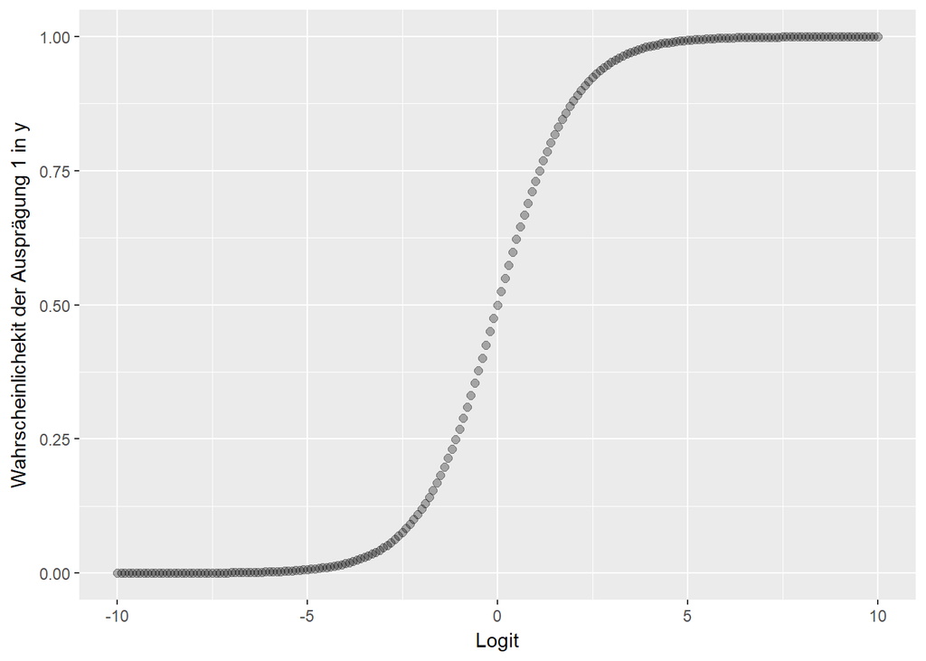

```r
logit_seq <- seq(-10, 10, by = .1)

prob_seq <- logit2prob(logit_seq)

df <- data.frame(Logit = logit_seq,
                 Wahrscheinlichkeit = prob_seq)

ggplot(df) +
  aes(x = logit_seq, y = prob_seq) +
  geom_point(size = 2, alpha = .3) +
  labs(x = "Logit", y = "Wahrscheinlichekit der Ausprägung 1 in y")
```